# Workshop on Latent Growth Modeling in Lavaan

Lifespan Cognitive Dynamics Lab

Nicholas Judd • Léa Michel • Jessica Schaaf • Magda Lazari • Rogier Kievit

24 March 2025

Welcome to this tutorial on Latent Growth Models (LGMs).

Latent Growth Models are structural equation models (SEM) that incorporate repeated observed measures of one variable to estimate the unobserved growth trajectory of that variable. Latent variables are unobserved variables. In latent growth models the growth trajectories are represented by the intercept and slope parameters, which are considered latent variables.

Lavaan notation cheat sheet: https://osf.io/q2prk

The dataset used for this workshop is called wisc. The WISC-V Test (Wechsler Intelligence Scale for Children) is an IQ test administered to children between ages 6 and 16. It provides five primary index scores, namely Verbal Comprehension Index, Visual Spatial Index, Fluid Reasoning Index, Working Memory Index, and Processing Speed Index. In the workshop you will work on a subset containing: Verbal Comprehension Index, Processing Speed Index and the total.

Now it’s time to get started!

## Content

### Getting started

The first step on this LGM adventure is to make sure all necessary programs and packages are installed. If you do not have R and/or its user-friendly interface, RStudio, installed, please do so via [this website](https://posit.co/download/rstudio-desktop/).

Then, within R, you need to install and load the lavaan package, which you are going to fit LGMs with.

**Assignment 1: Install and load the lavaan package.**

```r
if(!require("pacman")){install.packages("pacman",repos = "http://cran.us.r-project.org")}

pacman::p_load(lavaan, tidyverse, here, reshape2)
```

Now download the WISC data from the shared folder. Make sure that your R environment is linked to the folder in which you saved the data by setting your working directory.

**Assignment 2: Load the WISC data into R and explore which data are in the data file.**

```r
path <- "/Users/njudd/projects/LGC_Workshop/" #change to the LGC_Workshop folder

setwd(path)
wisc <- read.csv(paste0(path,"wisc.csv"))[,-1]

head(wisc)         #first 6 rows
```

```
##   ID Verbal_T6 Verbal_T7 Verbal_T9 Verbal_T11 Pspeed_T6 Pspeed_T7 Pspeed_T9
## 1  0  24.41964  26.97917  39.61310   55.63988 19.835937  22.96932  43.90245
## 2  1  12.44048  14.37500  21.91964   37.81250  5.898771  13.43888  18.28666
## 3  2  32.42560  33.51190  34.30060   50.17857 27.638263  45.02193  46.99432
## 4  3  22.69345  28.39286  42.15774   44.71726 33.158129  29.67703  45.97218
## 5  4  28.22917  37.81250  41.05655   70.95238 27.638263  44.41775  65.47530
## 6  5  16.05655  20.11905  38.02083   39.94048  8.445562  15.77845  26.98717
##   Pspeed_T11   Total_6  Total_7  Total_9 Total_11   age_T6 sex race mo_edu
## 1   44.18684 22.127790 24.97424 41.75777 49.91336 5.833333   1    1      4
## 2   40.38395  9.169624 13.90694 20.10315 39.09822 5.916667   2    2      6
## 3   77.71613 30.031929 39.26692 40.64746 63.94735 6.333333   1    1      2
## 4   61.66409 27.925791 29.03495 44.06496 53.19067 6.333333   2    1      2
## 5   64.21768 27.933715 41.11512 53.26593 67.58503 6.166667   1    1      3
## 6   39.08200 12.251055 17.94875 32.50400 39.51124 5.666667   1    1      2
##   mo_educat fa_edu fa_educat
## 1         0      4         0
## 2         0      5         0
## 3         2      3         1
## 4         2      2         2
## 5         1      3         1
## 6         2      2         2
```

```r
colnames(wisc)     #names of columns
```

```
##  [1] "ID"         "Verbal_T6"  "Verbal_T7"  "Verbal_T9"  "Verbal_T11"
##  [6] "Pspeed_T6"  "Pspeed_T7"  "Pspeed_T9"  "Pspeed_T11" "Total_6"
## [11] "Total_7"    "Total_9"    "Total_11"   "age_T6"     "sex"
## [16] "race"       "mo_edu"     "mo_educat"  "fa_edu"     "fa_educat"
```

```r
dim(wisc)          #number of rows and columns
```

```
## [1] 204  20
```

```r
sapply(wisc,class) #number of each column
```

```
##          ID   Verbal_T6   Verbal_T7   Verbal_T9  Verbal_T11   Pspeed_T6
##   "integer"   "numeric"   "numeric"   "numeric"   "numeric"   "numeric"
##   Pspeed_T7   Pspeed_T9  Pspeed_T11     Total_6     Total_7     Total_9
##   "numeric"   "numeric"   "numeric"   "numeric"   "numeric"   "numeric"
##    Total_11      age_T6         sex        race      mo_edu   mo_educat
##   "numeric"   "numeric"   "integer"   "integer"   "integer"   "integer"
##      fa_edu   fa_educat
## "character" "character"
```

For now, we are only going to analyze data from the verbal subtest (indicated by a column name that starts with “Verbal”).

**Assignment 3: Subset the data such that the dataset you work with only contains the id numbers and the scores on the verbal subtest across the four measurements. Your subset should thus contain five columns.**

```r
wisc_verbal <- wisc[,c("ID","Verbal_T6","Verbal_T7","Verbal_T9","Verbal_T11")]
```

As you may have noticed when exploring the data, they are in wide format, that is, they contain one row per participant and the different measurements are in separate columns. To fit models in Lavaan, this wide format is necessary. Yet, for plotting, it is easier if data are in long format, with one row per participant per measurement.

**Assignment 4: Reshape the data subset from wide to long format.**

```r
wisc_verbal_long <- wisc_verbal %>%
  pivot_longer(!ID, names_to = "wave", values_to = "verbal") #test
```

Now that we have prepared the data we want to model, let’s plot them!

**Assignment 5: Plot the data with the four measurements on the x-axis, the score on the verbal subtest on the y-axis, and a line for each subject.**

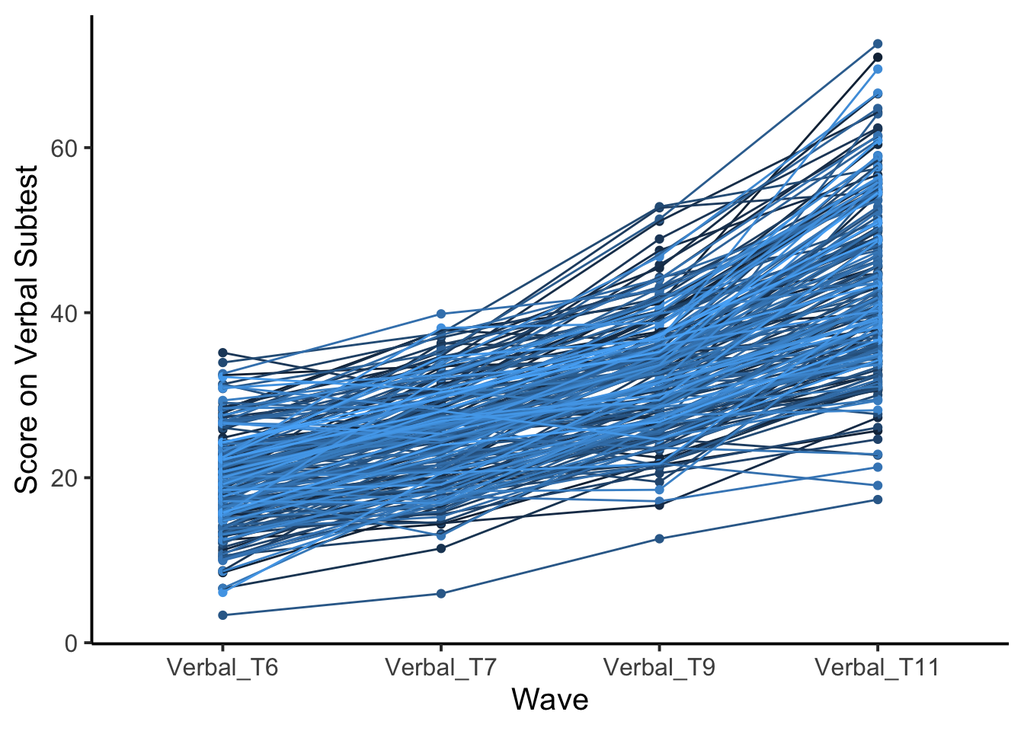

```r
wisc_verbal_long$wave = factor(wisc_verbal_long$wave, levels=c("Verbal_T6","Verbal_T7","Verbal_T9","Verbal_T11"))

ggplot(wisc_verbal_long, aes(wave, verbal, group=ID, fill=ID, color=ID)) +
  geom_point() +
  geom_line() +
  theme_classic(base_size = 15) + # adding a classic theme; https://ggplot2.tidyverse.org/reference/ggtheme.html
  theme(legend.position = "none") + # getting rid of legend
  labs(x = "Wave", y = "Score on Verbal Subtest")
```

To enable you to check whether your model implementation is correct in a later step, it is good to first formulate expectations based on the plotted data.

**Assignment 6: Describe what you see. What is the average score at each of the four measurements? Do subjects in- or decrease across measurements? Are there individual differences in these effects?**

You’re ready to move on to do some model fitting now. Click here to go back to the top to move on to the next module.

### Basic LGM in Lavaan

You are now going to actually fit an LGM in lavaan. We start simple.

**Assignment 7: Start by creating an empty string that you call linear_growth_model. Then try to implement an LGM in which you estimate (1) intercepts for each of the four time points, and (2) a *linear* slope. See the slides and the cheat sheet at the top for examples and hints.**

```r
# Create LGM
linear_growth_model <- '
  i =~ 1*Verbal_T6 + 1*Verbal_T7 + 1*Verbal_T9 + 1*Verbal_T11
  s =~ 0*Verbal_T6 + 1*Verbal_T7 + 2*Verbal_T9 + 3*Verbal_T11'
```

**Assignment 8: Fit the model you created in assignment 7 to the verbal subset data using the growth() function and plot results using summary().**

The lavaan::growth function is a wrapper function (for lavaan::lavaan) that simplifies the specification of growth models. See details in the help file: `?lavaan::growth`, for more info see `?lavaan::lavOptions`.

```r
# Fit LGM
fit_linear_growth_model <- growth(linear_growth_model, data=wisc_verbal,missing='fiml')
# Output results
summary(fit_linear_growth_model, fit.measures = TRUE, rsquare = TRUE, standardized = TRUE)
```

```
## lavaan 0.6-19 ended normally after 65 iterations
##
##   Estimator                                         ML
##   Optimization method                           NLMINB
##   Number of model parameters                         9
##
##   Number of observations                           204
##   Number of missing patterns                         1
##
## Model Test User Model:
##
##   Test statistic                               100.756
##   Degrees of freedom                                 5
##   P-value (Chi-square)                           0.000
##
## Model Test Baseline Model:
##
##   Test statistic                               585.906
##   Degrees of freedom                                 6
##   P-value                                        0.000
##
## User Model versus Baseline Model:
##
##   Comparative Fit Index (CFI)                    0.835
##   Tucker-Lewis Index (TLI)                       0.802
##
##   Robust Comparative Fit Index (CFI)             0.835
##   Robust Tucker-Lewis Index (TLI)                0.802
##
## Loglikelihood and Information Criteria:
##
##   Loglikelihood user model (H0)              -2530.194
##   Loglikelihood unrestricted model (H1)      -2479.816
##
##   Akaike (AIC)                                5078.388
##   Bayesian (BIC)                              5108.251
##   Sample-size adjusted Bayesian (SABIC)       5079.736
##
## Root Mean Square Error of Approximation:
##
```

[output cut: 45 more lines]

```
## Variances:
##                    Estimate  Std.Err  z-value  P(>|z|)   Std.lv  Std.all
##    .Verbal_T6        12.600    2.175    5.793    0.000   12.600    0.399
##    .Verbal_T7        10.213    1.463    6.982    0.000   10.213    0.250
##    .Verbal_T9        10.243    1.941    5.277    0.000   10.243    0.184
##    .Verbal_T11       45.410    5.781    7.855    0.000   45.410    0.417
##     i                18.961    3.154    6.012    0.000    1.000    1.000
##     s                 1.565    0.658    2.379    0.017    1.000    1.000
##
## R-Square:
##                    Estimate
##     Verbal_T6         0.601
##     Verbal_T7         0.750
##     Verbal_T9         0.816
##     Verbal_T11        0.583
```

**Assignment 9: How is model fit?**

**Assignment 10: What is the average verbal score at baseline? How does this compare to the expectations you formulated in assignment 6?**

**Assignment 11: What is the average change per wave?**

**Assignment 12: Are there individual differences in the score at baseline? And in how much individuals change?**

**Assignment 13: What does the score at baseline tell you about how much individuals change?**

Great! You have interpreted your first LGM output. Let’s make it a little more difficult in the next module.

### Uneven time intervals

Sometimes data collection does not happen every year, the intervals between two measures might be uneven. In the wisc data it seems that they measured the children at 6, 7, 9 and 11 years old.

**Assignment 14: Perform the same steps as in assignments 7, 8 and 14 but take into account the uneven time intervals in your loadings. Compare the three fits of the three models. Do you have the same result as in the previous assignments?**

```r
# Specify linear model
linear_growth_model_uneven <- ' i =~ 1*Verbal_T6 + 1*Verbal_T7 + 1*Verbal_T9 + 1*Verbal_T11
                                s =~ 6*Verbal_T6 + 7*Verbal_T7 + 9*Verbal_T9 + 11*Verbal_T11'

# Fit LGM
fit_linear_growth_model_uneven <- growth(linear_growth_model_uneven, data=wisc_verbal,missing='fiml')
# Output results
summary(fit_linear_growth_model_uneven, fit.measures = TRUE, rsquare = TRUE, standardized = TRUE)
```

```
## lavaan 0.6-19 ended normally after 51 iterations
##
##   Estimator                                         ML
##   Optimization method                           NLMINB
##   Number of model parameters                         9
##
##   Number of observations                           204
##   Number of missing patterns                         1
##
## Model Test User Model:
##
##   Test statistic                                54.917
##   Degrees of freedom                                 5
##   P-value (Chi-square)                           0.000
##
## Model Test Baseline Model:
##
##   Test statistic                               585.906
##   Degrees of freedom                                 6
##   P-value                                        0.000
##
## User Model versus Baseline Model:
##
##   Comparative Fit Index (CFI)                    0.914
##   Tucker-Lewis Index (TLI)                       0.897
##
##   Robust Comparative Fit Index (CFI)             0.914
##   Robust Tucker-Lewis Index (TLI)                0.897
##
## Loglikelihood and Information Criteria:
##
##   Loglikelihood user model (H0)              -2507.274
##   Loglikelihood unrestricted model (H1)      -2479.816
##
##   Akaike (AIC)                                5032.548
##   Bayesian (BIC)                              5062.411
##   Sample-size adjusted Bayesian (SABIC)       5033.897
##
## Root Mean Square Error of Approximation:
##
```

[output cut: 45 more lines]

```
## Variances:
##                    Estimate  Std.Err  z-value  P(>|z|)   Std.lv  Std.all
##    .Verbal_T6        10.504    1.731    6.069    0.000   10.504    0.331
##    .Verbal_T7        10.972    1.486    7.384    0.000   10.972    0.280
##    .Verbal_T9        10.452    1.830    5.713    0.000   10.452    0.179
##    .Verbal_T11       29.870    4.672    6.394    0.000   29.870    0.285
##     i                18.076   11.774    1.535    0.125    1.000    1.000
##     s                 0.926    0.240    3.852    0.000    1.000    1.000
##
## R-Square:
##                    Estimate
##     Verbal_T6         0.669
##     Verbal_T7         0.720
##     Verbal_T9         0.821
##     Verbal_T11        0.715
```

A recommendation is that, if time intervals are unequal, it may be better to use measured time.

### Different Shapes of Growth

In the previous module, we modeled a linear growth model. Yet, it is also possible to model non-linear growth in lavaan like a quadratic trajectory. For this you need to add a third parameter called a quadratic term that will get the same loadings as for the slope but squared. To do this, you need to specify one more latent variable in your model called quadratic term. The quadratic term is given loadings that are the squares of the loadings for the slope.

**Assignment 15: Create a quadratic growth model, fit it to the verbal data, and output results.**

```r
# Create quadratic growth model
quad_growth_model <- 'i =~ 1*Verbal_T6 + 1*Verbal_T7 + 1*Verbal_T9 + 1*Verbal_T11
                      s =~ 0*Verbal_T6 + 1*Verbal_T7 + 2*Verbal_T9 + 3*Verbal_T11
                      q =~ 0*Verbal_T6 + 1*Verbal_T7 + 4*Verbal_T9 + 9*Verbal_T11'
# Fit model
fit_quad_growth_model <- growth(quad_growth_model, data=wisc_verbal,missing='fiml')
# Output results
summary(fit_quad_growth_model, fit.measures = TRUE, rsquare = TRUE, standardized = TRUE)
```

```
## lavaan 0.6-19 ended normally after 99 iterations
##
##   Estimator                                         ML
##   Optimization method                           NLMINB
##   Number of model parameters                        13
##
##   Number of observations                           204
##   Number of missing patterns                         1
##
## Model Test User Model:
##
##   Test statistic                                 6.176
##   Degrees of freedom                                 1
##   P-value (Chi-square)                           0.013
##
## Model Test Baseline Model:
##
##   Test statistic                               585.906
##   Degrees of freedom                                 6
##   P-value                                        0.000
##
## User Model versus Baseline Model:
##
##   Comparative Fit Index (CFI)                    0.991
##   Tucker-Lewis Index (TLI)                       0.946
##
##   Robust Comparative Fit Index (CFI)             0.991
##   Robust Tucker-Lewis Index (TLI)                0.946
##
## Loglikelihood and Information Criteria:
##
##   Loglikelihood user model (H0)              -2482.904
##   Loglikelihood unrestricted model (H1)      -2479.816
##
##   Akaike (AIC)                                4991.808
##   Bayesian (BIC)                              5034.943
##   Sample-size adjusted Bayesian (SABIC)       4993.755
##
## Root Mean Square Error of Approximation:
##
```

[output cut: 55 more lines]

```
##                    Estimate  Std.Err  z-value  P(>|z|)   Std.lv  Std.all
##    .Verbal_T6         9.730    6.209    1.567    0.117    9.730    0.290
##    .Verbal_T7        11.059    2.297    4.814    0.000   11.059    0.297
##    .Verbal_T9         9.542    2.677    3.564    0.000    9.542    0.179
##    .Verbal_T11       29.417   11.518    2.554    0.011   29.417    0.260
##     i                23.848    6.558    3.636    0.000    1.000    1.000
##     s                -3.277    7.053   -0.465    0.642       NA       NA
##     q                -0.312    0.656   -0.476    0.634       NA       NA
##
## R-Square:
##                    Estimate
##     Verbal_T6         0.710
##     Verbal_T7         0.703
##     Verbal_T9         0.821
##     Verbal_T11        0.740
```

```r
#
```

**Assignment 16: How is model fit?**

**Assignment 17: What is the average verbal score at baseline? Does this estimate differ from the estimate in assignment 10? And from your expectations?**

**Assignment 18: What is the shape of change across measurements?**

**Assignment 19: You have an error message. What does it mean? Can you see where is the issue in the output?**

It is also possible to model non-linear growth in lavaan with no hypothesis on the shape. To do so, you fix the loadings of the first and last measurement, but freely estimate the middle ones.

**Assignment 20: Create a non-linear (basis) growth model, fit it to the verbal data, and output results. Then compare the model fit with the previous models.**

```r
# Create non-linear growth model
basis_growth_model <- 'i =~ 1*Verbal_T6 + 1*Verbal_T7 + 1*Verbal_T9 + 1*Verbal_T11
                       s =~ 0*Verbal_T6 + Verbal_T7 + Verbal_T9 + 1*Verbal_T11'
# Fit model
fit_basis_growth_model <- growth(basis_growth_model, data=wisc_verbal,missing='fiml')
# Output results
summary(fit_basis_growth_model, fit.measures = TRUE, rsquare = TRUE, standardized = TRUE)
```

```
## lavaan 0.6-19 ended normally after 109 iterations
##
##   Estimator                                         ML
##   Optimization method                           NLMINB
##   Number of model parameters                        11
##
##   Number of observations                           204
##   Number of missing patterns                         1
##
## Model Test User Model:
##
##   Test statistic                                 5.893
##   Degrees of freedom                                 3
##   P-value (Chi-square)                           0.117
##
## Model Test Baseline Model:
##
##   Test statistic                               585.906
##   Degrees of freedom                                 6
##   P-value                                        0.000
##
## User Model versus Baseline Model:
##
##   Comparative Fit Index (CFI)                    0.995
##   Tucker-Lewis Index (TLI)                       0.990
##
##   Robust Comparative Fit Index (CFI)             0.995
##   Robust Tucker-Lewis Index (TLI)                0.990
##
## Loglikelihood and Information Criteria:
##
##   Loglikelihood user model (H0)              -2482.763
##   Loglikelihood unrestricted model (H1)      -2479.816
##
##   Akaike (AIC)                                4987.525
##   Bayesian (BIC)                              5024.024
##   Sample-size adjusted Bayesian (SABIC)       4989.173
##
## Root Mean Square Error of Approximation:
##
```

[output cut: 45 more lines]

```
## Variances:
##                    Estimate  Std.Err  z-value  P(>|z|)   Std.lv  Std.all
##    .Verbal_T6         9.974    1.645    6.063    0.000    9.974    0.319
##    .Verbal_T7         9.704    1.307    7.422    0.000    9.704    0.244
##    .Verbal_T9         9.217    1.513    6.093    0.000    9.217    0.167
##    .Verbal_T11       25.340    4.317    5.870    0.000   25.340    0.237
##     i                21.255    2.898    7.335    0.000    1.000    1.000
##     s                30.076    6.788    4.430    0.000    1.000    1.000
##
## R-Square:
##                    Estimate
##     Verbal_T6         0.681
##     Verbal_T7         0.756
##     Verbal_T9         0.833
##     Verbal_T11        0.763
```

**Assignment 21: Perform a statistical test to compare model fit. Does the linear or non-linear model fit better?**

```r
# Compare model fit
anova(fit_basis_growth_model,fit_linear_growth_model)
```

```
##
## Chi-Squared Difference Test
##
##                         Df    AIC    BIC    Chisq Chisq diff   RMSEA Df diff
## fit_basis_growth_model   3 4987.5 5024.0   5.8934
## fit_linear_growth_model  5 5078.4 5108.3 100.7562     94.863 0.47708       2
##                         Pr(>Chisq)
## fit_basis_growth_model
## fit_linear_growth_model  < 2.2e-16 ***
## ---
## Signif. codes:  0 '***' 0.001 '**' 0.01 '*' 0.05 '.' 0.1 ' ' 1
```

```r
#Here it looks like the basis model fits better
```

**Assignment 22: Can you make a Quadratic with uneven time intervals and compare it to the linear?**

```r
# Specify quadratic model
quad_growth_model_uneven <- ' i =~ 1*Verbal_T6 + 1*Verbal_T7 + 1*Verbal_T9 + 1*Verbal_T11
                                s =~ 6*Verbal_T6 + 7*Verbal_T7 + 9*Verbal_T9 + 11*Verbal_T11
                                q =~ 36*Verbal_T6 + 49*Verbal_T7 + 81*Verbal_T9 + 121*Verbal_T11'

# Fit LGM
fit_quad_growth_model_uneven <- growth(quad_growth_model_uneven, data=wisc_verbal,missing='fiml')
# Output results
summary(fit_quad_growth_model_uneven, fit.measures = TRUE, rsquare = TRUE, standardized = TRUE)
```

```
## lavaan 0.6-19 ended normally after 100 iterations
##
##   Estimator                                         ML
##   Optimization method                           NLMINB
##   Number of model parameters                        13
##
##   Number of observations                           204
##   Number of missing patterns                         1
##
## Model Test User Model:
##
##   Test statistic                                39.104
##   Degrees of freedom                                 1
##   P-value (Chi-square)                           0.000
##
## Model Test Baseline Model:
##
##   Test statistic                               585.906
##   Degrees of freedom                                 6
##   P-value                                        0.000
##
## User Model versus Baseline Model:
##
##   Comparative Fit Index (CFI)                    0.934
##   Tucker-Lewis Index (TLI)                       0.606
##
##   Robust Comparative Fit Index (CFI)             0.934
##   Robust Tucker-Lewis Index (TLI)                0.606
##
## Loglikelihood and Information Criteria:
##
##   Loglikelihood user model (H0)              -2499.368
##   Loglikelihood unrestricted model (H1)      -2479.816
##
##   Akaike (AIC)                                5024.736
##   Bayesian (BIC)                              5067.871
##   Sample-size adjusted Bayesian (SABIC)       5026.684
##
## Root Mean Square Error of Approximation:
##
```

[output cut: 55 more lines]

```
##                    Estimate  Std.Err  z-value  P(>|z|)   Std.lv  Std.all
##    .Verbal_T6        11.332    4.050    2.798    0.005   11.332    0.335
##    .Verbal_T7        12.827    2.401    5.342    0.000   12.827    0.334
##    .Verbal_T9        10.707    4.073    2.628    0.009   10.707    0.199
##    .Verbal_T11       42.441   19.671    2.157    0.031   42.441    0.373
##     i              -706.425  428.026   -1.650    0.099       NA       NA
##     s               -51.974   26.584   -1.955    0.051       NA       NA
##     q                -0.200    0.114   -1.760    0.078       NA       NA
##
## R-Square:
##                    Estimate
##     Verbal_T6         0.665
##     Verbal_T7         0.666
##     Verbal_T9         0.801
##     Verbal_T11        0.627
```

```r
#You should get the warning message "In lav_object_post_check(object) : lavaan WARNING: some estimated lv variances are negative"

# Compare linear model fit between the model not taking into account the uneven intervals and the one taking into account the uneven intervals
anova(fit_linear_growth_model_uneven,fit_linear_growth_model)
```

```
##
## Chi-Squared Difference Test
##
##                                Df    AIC    BIC   Chisq Chisq diff RMSEA
## fit_linear_growth_model_uneven  5 5032.5 5062.4  54.916
## fit_linear_growth_model         5 5078.4 5108.3 100.756      45.84     0
##                                Df diff Pr(>Chisq)
## fit_linear_growth_model_uneven
## fit_linear_growth_model              0
```

```r
#You cannot compare these models

# Compare model fit between linear trajectory with uneven intervals and the basis model
anova(fit_linear_growth_model_uneven,fit_basis_growth_model)
```

```
##
## Chi-Squared Difference Test
##
##                                Df    AIC    BIC   Chisq Chisq diff   RMSEA
## fit_basis_growth_model          3 4987.5 5024.0  5.8934
## fit_linear_growth_model_uneven  5 5032.5 5062.4 54.9165     49.023 0.33949
##                                Df diff Pr(>Chisq)
## fit_basis_growth_model
## fit_linear_growth_model_uneven       2  2.263e-11 ***
## ---
## Signif. codes:  0 '***' 0.001 '**' 0.01 '*' 0.05 '.' 0.1 ' ' 1
```

```r
#Here it looks like the basis model is preferred.
```

Congrats! You can now choose the best shape for your trajectory. Let’s add predictors in the next module.

### Predictors and outcomes

One may be interested in what predicts baseline scores and/or change. To assess this, one can add predictors in the growth model. One hypothesis could be that the level of education of the mother predicts the development of verbal comprehension.

**Assignment 23: Add educational level of the mother (mo_edu in the data file) as predictor of baseline scores and change in the non-linear model.**

```r
# Specify model
basis_growth_model_cov <- '
  i =~ 1*Verbal_T6 + 1*Verbal_T7 + 1*Verbal_T9 + 1*Verbal_T11
  s =~ 0*Verbal_T6 + Verbal_T7 + Verbal_T9 + 1*Verbal_T11
  s~mo_edu
  i~mo_edu
  '
```

```r
# Fit model
fit_basis_growth_model_cov <- growth(basis_growth_model_cov, data=wisc,missing='fiml')
# Output results
summary(fit_basis_growth_model_cov, fit.measures = TRUE, rsquare = TRUE, standardized = TRUE)
```

```
## lavaan 0.6-19 ended normally after 118 iterations
##
##   Estimator                                         ML
##   Optimization method                           NLMINB
##   Number of model parameters                        13
##
##   Number of observations                           204
##   Number of missing patterns                         1
##
## Model Test User Model:
##
##   Test statistic                                 6.498
##   Degrees of freedom                                 5
##   P-value (Chi-square)                           0.261
##
## Model Test Baseline Model:
##
##   Test statistic                               650.266
##   Degrees of freedom                                10
##   P-value                                        0.000
##
## User Model versus Baseline Model:
##
##   Comparative Fit Index (CFI)                    0.998
##   Tucker-Lewis Index (TLI)                       0.995
##
##   Robust Comparative Fit Index (CFI)             0.998
##   Robust Tucker-Lewis Index (TLI)                0.995
##
## Loglikelihood and Information Criteria:
##
##   Loglikelihood user model (H0)              -2450.885
##   Loglikelihood unrestricted model (H1)      -2447.636
##
##   Akaike (AIC)                                4927.770
##   Bayesian (BIC)                              4970.906
##   Sample-size adjusted Bayesian (SABIC)       4929.718
##
## Root Mean Square Error of Approximation:
##
```

[output cut: 54 more lines]

```
##    .Verbal_T6         9.923    1.622    6.117    0.000    9.923    0.318
##    .Verbal_T7         9.607    1.281    7.500    0.000    9.607    0.242
##    .Verbal_T9         9.443    1.501    6.291    0.000    9.443    0.170
##    .Verbal_T11       24.956    4.288    5.820    0.000   24.956    0.234
##    .i                15.298    2.309    6.624    0.000    0.718    0.718
##    .s                25.619    6.352    4.033    0.000    0.844    0.844
##
## R-Square:
##                    Estimate
##     Verbal_T6         0.682
##     Verbal_T7         0.758
##     Verbal_T9         0.830
##     Verbal_T11        0.766
##     i                 0.282
##     s                 0.156
```

**Assignment 25: Add processing speed at 11 as an outcome of changes in verbal comprehension. In other words, test if the slopes of verbal change predict the level of processing speed at 11.**

```r
# Specify model
basis_growth_model_covO <- '
  i =~ 1*Verbal_T6 + 1*Verbal_T7 + 1*Verbal_T9 + 1*Verbal_T11
  s =~ 0*Verbal_T6 + Verbal_T7 + Verbal_T9 + 1*Verbal_T11
  Pspeed_T11~s
  Pspeed_T11~1
'
# Fit model
fit_basis_growth_model_covO <- growth(basis_growth_model_covO, data=wisc,missing='fiml')
# Output results
summary(fit_basis_growth_model_covO, fit.measures = TRUE, rsquare = TRUE, standardized = TRUE)
```

```
## lavaan 0.6-19 ended normally after 142 iterations
##
##   Estimator                                         ML
##   Optimization method                           NLMINB
##   Number of model parameters                        14
##
##   Number of observations                           204
##   Number of missing patterns                         1
##
## Model Test User Model:
##
##   Test statistic                                14.016
##   Degrees of freedom                                 6
##   P-value (Chi-square)                           0.029
##
## Model Test Baseline Model:
##
##   Test statistic                               685.769
##   Degrees of freedom                                10
##   P-value                                        0.000
##
## User Model versus Baseline Model:
##
##   Comparative Fit Index (CFI)                    0.988
##   Tucker-Lewis Index (TLI)                       0.980
##
##   Robust Comparative Fit Index (CFI)             0.988
##   Robust Tucker-Lewis Index (TLI)                0.980
##
## Loglikelihood and Information Criteria:
##
##   Loglikelihood user model (H0)              -3240.780
##   Loglikelihood unrestricted model (H1)      -3233.772
##
##   Akaike (AIC)                                6509.560
##   Bayesian (BIC)                              6556.014
##   Sample-size adjusted Bayesian (SABIC)       6511.657
##
## Root Mean Square Error of Approximation:
##
```

[output cut: 53 more lines]

```
##    .Verbal_T6        10.997    1.451    7.578    0.000   10.997    0.354
##    .Verbal_T7         9.658    1.299    7.436    0.000    9.658    0.246
##    .Verbal_T9        10.154    1.529    6.640    0.000   10.154    0.181
##    .Verbal_T11       25.254    3.694    6.836    0.000   25.254    0.238
##    .Pspeed_T11       79.657   10.996    7.244    0.000   79.657    0.514
##     i                20.036    2.643    7.580    0.000    1.000    1.000
##     s                26.598    5.701    4.666    0.000    1.000    1.000
##
## R-Square:
##                    Estimate
##     Verbal_T6         0.646
##     Verbal_T7         0.754
##     Verbal_T9         0.819
##     Verbal_T11        0.762
##     Pspeed_T11        0.486
```

```r
# Specify model
basis_growth_model_covP <- '
  i =~ 1*Verbal_T6 + 1*Verbal_T7 + 1*Verbal_T9 + 1*Verbal_T11
  s =~ 0*Verbal_T6 + Verbal_T7 + Verbal_T9 + 1*Verbal_T11
  s~Pspeed_T6
  i~Pspeed_T6
  i~~s
'
# Fit model
fit_basis_growth_model_covP <- growth(basis_growth_model_covP, data=wisc,missing='fiml')
# Output results
summary(fit_basis_growth_model_covP, fit.measures = TRUE, rsquare = TRUE, standardized = TRUE)
```

```
## lavaan 0.6-19 ended normally after 92 iterations
##
##   Estimator                                         ML
##   Optimization method                           NLMINB
##   Number of model parameters                        13
##
##   Number of observations                           204
##   Number of missing patterns                         1
##
## Model Test User Model:
##
##   Test statistic                                 8.737
##   Degrees of freedom                                 5
##   P-value (Chi-square)                           0.120
##
## Model Test Baseline Model:
##
##   Test statistic                               715.505
##   Degrees of freedom                                10
##   P-value                                        0.000
##
## User Model versus Baseline Model:
##
##   Comparative Fit Index (CFI)                    0.995
##   Tucker-Lewis Index (TLI)                       0.989
##
##   Robust Comparative Fit Index (CFI)             0.995
##   Robust Tucker-Lewis Index (TLI)                0.989
##
## Loglikelihood and Information Criteria:
##
##   Loglikelihood user model (H0)              -2419.385
##   Loglikelihood unrestricted model (H1)      -2415.016
##
##   Akaike (AIC)                                4864.769
##   Bayesian (BIC)                              4907.905
##   Sample-size adjusted Bayesian (SABIC)       4866.717
##
## Root Mean Square Error of Approximation:
##
```

[output cut: 54 more lines]

```
##    .Verbal_T6         9.436    1.592    5.926    0.000    9.436    0.304
##    .Verbal_T7         9.950    1.290    7.711    0.000    9.950    0.247
##    .Verbal_T9         9.531    1.473    6.470    0.000    9.531    0.171
##    .Verbal_T11       24.122    4.217    5.720    0.000   24.122    0.227
##    .i                11.302    1.895    5.964    0.000    0.524    0.524
##    .s                22.767    6.034    3.773    0.000    0.729    0.729
##
## R-Square:
##                    Estimate
##     Verbal_T6         0.696
##     Verbal_T7         0.753
##     Verbal_T9         0.829
##     Verbal_T11        0.773
##     i                 0.476
##     s                 0.271
```

**Extra**

Time-invariant predictors are predictors of the individual differences in intercepts and slopes.They are often measurement at baseline (e.g., family income) or person-specific characteristics where value is constant over time (e.g., biological sex, country of origin). For instance, in the previous assignments, level of education of the mother and processing speed at 6 are time-invariant predictors. Time-varying predictors are predictors of the outcome at each time point. In our example for instance we would need measurements at T6, T7, T9 and T11

**Assignment 27: Use processing speed as a time-varying predictor of the verbal measurement at each time point. How are the intercept and slope of the verbal measures? Does processing speed predict verbal measures the same way across time points?**

```r
# Specify model
basis_growth_model_tvp <- '
  i =~ 1*Verbal_T6 + 1*Verbal_T7 + 1*Verbal_T9 + 1*Verbal_T11
  s =~ 0*Verbal_T6 + Verbal_T7 + Verbal_T9 + 1*Verbal_T11
  Verbal_T6~Pspeed_T6
  Verbal_T7~Pspeed_T7
  Verbal_T9~Pspeed_T9
  Verbal_T11~Pspeed_T11
  '
# Fit LGM
fit_basis_growth_model_tvp <- growth(basis_growth_model_tvp, data=wisc,missing='fiml')
# Output results
summary(fit_basis_growth_model_tvp, fit.measures = TRUE, rsquare = TRUE, standardized = TRUE)
```

```
## lavaan 0.6-19 ended normally after 96 iterations
##
##   Estimator                                         ML
##   Optimization method                           NLMINB
##   Number of model parameters                        15
##
##   Number of observations                           204
##   Number of missing patterns                         1
##
## Model Test User Model:
##
##   Test statistic                                90.277
##   Degrees of freedom                                15
##   P-value (Chi-square)                           0.000
##
## Model Test Baseline Model:
##
##   Test statistic                               754.793
##   Degrees of freedom                                22
##   P-value                                        0.000
##
## User Model versus Baseline Model:
##
##   Comparative Fit Index (CFI)                    0.897
##   Tucker-Lewis Index (TLI)                       0.849
##
##   Robust Comparative Fit Index (CFI)             0.897
##   Robust Tucker-Lewis Index (TLI)                0.849
##
## Loglikelihood and Information Criteria:
##
##   Loglikelihood user model (H0)              -2440.511
##   Loglikelihood unrestricted model (H1)      -2395.373
##
##   Akaike (AIC)                                4911.022
##   Bayesian (BIC)                              4960.794
##   Sample-size adjusted Bayesian (SABIC)       4913.269
##
## Root Mean Square Error of Approximation:
##
```

[output cut: 56 more lines]

```
## Variances:
##                    Estimate  Std.Err  z-value  P(>|z|)   Std.lv  Std.all
##    .Verbal_T6         8.814    1.705    5.170    0.000    8.814    0.338
##    .Verbal_T7         9.806    1.311    7.478    0.000    9.806    0.292
##    .Verbal_T9         9.583    1.978    4.846    0.000    9.583    0.208
##    .Verbal_T11       27.351    4.282    6.387    0.000   27.351    0.310
##     i                13.165    2.347    5.609    0.000    1.000    1.000
##     s                20.235    6.197    3.265    0.001    1.000    1.000
##
## R-Square:
##                    Estimate
##     Verbal_T6         0.662
##     Verbal_T7         0.708
##     Verbal_T9         0.792
##     Verbal_T11        0.690
```

You’re ready to add a bit more complexity to those models. Click here to go back to the top to move on to the next module.

### Intercept and slopes relations

Now that you know how to estimate the trajectory of one variable you are able to estimate the trajectory of two variables and see how they interact.

**Assignment 28: Create two non-linear (basis) growth models, one for verbal and one for processing speed. Correlate the changes of the two metrics. Are their slopes correlated?**

```r
# Specify model
basis_growth_model_cor_ver_pro <- '
  i_verbal =~ 1*Verbal_T6 + 1*Verbal_T7 + 1*Verbal_T9 + 1*Verbal_T11
  s_verbal =~ 0*Verbal_T6 + Verbal_T7 + Verbal_T9 + 1*Verbal_T11
  i_processpeed =~ 1*Pspeed_T6 + 1*Pspeed_T7 + 1*Pspeed_T9 + 1*Pspeed_T11
  s_processpeed =~ 0*Pspeed_T6 + Pspeed_T7 + Pspeed_T9 + 1*Pspeed_T11
  s_verbal ~~ s_processpeed'

# Fit LGM
fit_basis_growth_model_cor_ver_pro <- growth(basis_growth_model_cor_ver_pro, data=wisc,missing='fiml')
# Output results
summary(fit_basis_growth_model_cor_ver_pro, fit.measures = TRUE, rsquare = TRUE, standardized = TRUE)
```

```
## lavaan 0.6-19 ended normally after 211 iterations
##
##   Estimator                                         ML
##   Optimization method                           NLMINB
##   Number of model parameters                        26
##
##   Number of observations                           204
##   Number of missing patterns                         1
##
## Model Test User Model:
##
##   Test statistic                                29.305
##   Degrees of freedom                                18
##   P-value (Chi-square)                           0.045
##
## Model Test Baseline Model:
##
##   Test statistic                              1423.083
##   Degrees of freedom                                28
##   P-value                                        0.000
##
## User Model versus Baseline Model:
##
##   Comparative Fit Index (CFI)                    0.992
##   Tucker-Lewis Index (TLI)                       0.987
##
##   Robust Comparative Fit Index (CFI)             0.992
##   Robust Tucker-Lewis Index (TLI)                0.987
##
## Loglikelihood and Information Criteria:
##
##   Loglikelihood user model (H0)              -5124.285
##   Loglikelihood unrestricted model (H1)      -5109.632
##
##   Akaike (AIC)                               10300.570
##   Bayesian (BIC)                             10386.841
##   Sample-size adjusted Bayesian (SABIC)      10304.465
##
## Root Mean Square Error of Approximation:
##
```

[output cut: 75 more lines]

```
##     i_verbal         21.502    2.893    7.432    0.000    1.000    1.000
##     s_verbal         32.425    6.990    4.639    0.000    1.000    1.000
##     i_processpeed    57.821    6.889    8.393    0.000    1.000    1.000
##     s_processpeed    38.226    8.968    4.263    0.000    1.000    1.000
##
## R-Square:
##                    Estimate
##     Verbal_T6         0.692
##     Verbal_T7         0.757
##     Verbal_T9         0.820
##     Verbal_T11        0.788
##     Pspeed_T6         0.813
##     Pspeed_T7         0.775
##     Pspeed_T9         0.820
##     Pspeed_T11        0.830
```

**Assignment 29: Within that model, explore how one metrics baseline level predicts the changes in the other. How do they predict each other?**

```r
# Specify model
basis_growth_model_pred_ver_pro <- '
  i_verbal =~ 1*Verbal_T6 + 1*Verbal_T7 + 1*Verbal_T9 + 1*Verbal_T11
  s_verbal =~ 0*Verbal_T6 + Verbal_T7 + Verbal_T9 + 1*Verbal_T11
  i_processpeed =~ 1*Pspeed_T6 + 1*Pspeed_T7 + 1*Pspeed_T9 + 1*Pspeed_T11
  s_processpeed =~ 0*Pspeed_T6 + Pspeed_T7 + Pspeed_T9 + 1*Pspeed_T11
  s_verbal ~ i_processpeed
  s_processpeed ~ i_verbal'

# Fit LGM
fit_basis_growth_model_pred_ver_pro <- growth(basis_growth_model_pred_ver_pro, data=wisc,missing='fiml')
# Output results
summary(fit_basis_growth_model_pred_ver_pro, fit.measures = TRUE, rsquare = TRUE, standardized = TRUE)
```

```
## lavaan 0.6-19 ended normally after 175 iterations
##
##   Estimator                                         ML
##   Optimization method                           NLMINB
##   Number of model parameters                        24
##
##   Number of observations                           204
##   Number of missing patterns                         1
##
## Model Test User Model:
##
##   Test statistic                                38.158
##   Degrees of freedom                                20
##   P-value (Chi-square)                           0.008
##
## Model Test Baseline Model:
##
##   Test statistic                              1423.083
##   Degrees of freedom                                28
##   P-value                                        0.000
##
## User Model versus Baseline Model:
##
##   Comparative Fit Index (CFI)                    0.987
##   Tucker-Lewis Index (TLI)                       0.982
##
##   Robust Comparative Fit Index (CFI)             0.987
##   Robust Tucker-Lewis Index (TLI)                0.982
##
## Loglikelihood and Information Criteria:
##
##   Loglikelihood user model (H0)              -5128.711
##   Loglikelihood unrestricted model (H1)      -5109.632
##
##   Akaike (AIC)                               10305.422
##   Bayesian (BIC)                             10385.057
##   Sample-size adjusted Bayesian (SABIC)      10309.018
##
## Root Mean Square Error of Approximation:
##
```

[output cut: 78 more lines]

```
##     i_processpeed    61.801    6.889    8.971    0.000    1.000    1.000
##    .s_processpeed    47.685    8.194    5.820    0.000    0.990    0.990
##
## R-Square:
##                    Estimate
##     Verbal_T6         0.733
##     Verbal_T7         0.757
##     Verbal_T9         0.812
##     Verbal_T11        0.793
##     Pspeed_T6         0.863
##     Pspeed_T7         0.764
##     Pspeed_T9         0.804
##     Pspeed_T11        0.835
##     s_verbal          0.288
##     s_processpeed     0.010
```

Let’s finish with simulation of data. Click here to go back to the top to move on to the next module.

### Simulate your data [extra]

Data simulation is a useful tool to test your models and do power analysis,

```r
# Specify linear model
sim_lgm_4waves<- '
i =~ 1*t1 + 1*t2 + 1*t3 + 1*t4
s =~ 0*t1 + 1*t2 + 2*t3 + 3*t4

i~100*1         ##<## this specifies the intercept, or the mean at T1
i~~15*i         ##<## this specifies the intercept variance at T1

s~5*1           ##<## this specifies the slope, or change per wave
s~~10*s         ##<## this specifies the slope variance

i~~-3*s         ##<## this specifies the intercept/slope covariance

'
sim_lgm_4waves_dat <- simulateData(sim_lgm_4waves, sample.nobs = 500)

#Sanity check of the column means. As expected the scores increase ~ 5 points per wave
colMeans(sim_lgm_4waves_dat)
```

```
##        t1        t2        t3        t4
##  99.72839 104.84006 110.10505 115.20710
```

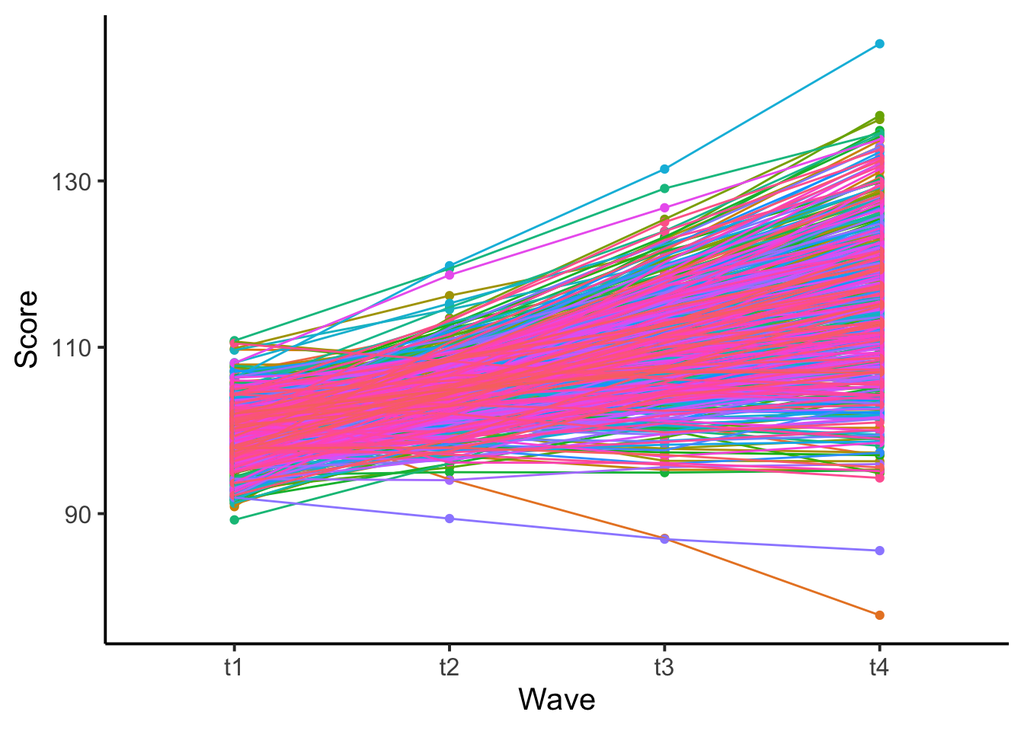

```r
#Plotting. Now you can start tweaking parameters to see what the data looks like
sim_lgm_4waves_dat$id<-as.factor(1:nrow(sim_lgm_4waves_dat))
theme_set(theme_grey(base_size = 18)) #increase text size
plotdat<-melt(sim_lgm_4waves_dat)

ggplot(plotdat, aes(variable,value,group=id, fill=id, color=id)) +
  geom_point() +
  geom_line() +
  theme_classic(base_size = 15) + # adding a classic theme; https://ggplot2.tidyverse.org/reference/ggtheme.html
  theme(legend.position = "none") + # getting rid of legend
  labs(x = "Wave", y = "Score")
```

```r
# Specify linear model
fit_lgm_4waves<- '
i =~ 1*t1 + 1*t2 + 1*t3 + 1*t4
s =~ 0*t1 + 1*t2 + 2*t3 + 3*t4
i~~s
'

# Fit LGM
fit_fit_lgm_4waves <- growth(fit_lgm_4waves, data=sim_lgm_4waves_dat,missing='fiml')
# Output results
summary(fit_fit_lgm_4waves, fit.measures=TRUE, standardized=TRUE, rsquare=TRUE,ci=T)
```

```
## lavaan 0.6-19 ended normally after 153 iterations
##
##   Estimator                                         ML
##   Optimization method                           NLMINB
##   Number of model parameters                         9
##
##   Number of observations                           500
##   Number of missing patterns                         1
##
## Model Test User Model:
##
##   Test statistic                                 3.008
##   Degrees of freedom                                 5
##   P-value (Chi-square)                           0.699
##
## Model Test Baseline Model:
##
##   Test statistic                              2876.258
##   Degrees of freedom                                 6
##   P-value                                        0.000
##
## User Model versus Baseline Model:
##
##   Comparative Fit Index (CFI)                    1.000
##   Tucker-Lewis Index (TLI)                       1.001
##
##   Robust Comparative Fit Index (CFI)             1.000
##   Robust Tucker-Lewis Index (TLI)                1.001
##
## Loglikelihood and Information Criteria:
##
##   Loglikelihood user model (H0)              -4825.994
##   Loglikelihood unrestricted model (H1)      -4824.490
##
##   Akaike (AIC)                                9669.987
##   Bayesian (BIC)                              9707.919
##   Sample-size adjusted Bayesian (SABIC)       9679.352
##
## Root Mean Square Error of Approximation:
##
```

[output cut: 69 more lines]

```
##     s                10.811    0.697   15.507    0.000    9.444   12.177
##    Std.lv  Std.all
##     0.988    0.066
##     0.992    0.058
##     1.013    0.025
##     1.077    0.012
##     1.000    1.000
##     1.000    1.000
##
## R-Square:
##                    Estimate
##     t1                0.934
##     t2                0.942
##     t3                0.975
##     t4                0.988
```

```r
parTable(fit_fit_lgm_4waves)   #Parameters are recovered nicely
```

```
##    id lhs op rhs user block group free ustart exo label plabel  start    est
## 1   1   i =~  t1    1     1     1    0      1   0         .p1.  1.000  1.000
## 2   2   i =~  t2    1     1     1    0      1   0         .p2.  1.000  1.000
## 3   3   i =~  t3    1     1     1    0      1   0         .p3.  1.000  1.000
## 4   4   i =~  t4    1     1     1    0      1   0         .p4.  1.000  1.000
## 5   5   s =~  t1    1     1     1    0      0   0         .p5.  0.000  0.000
## 6   6   s =~  t2    1     1     1    0      1   0         .p6.  1.000  1.000
## 7   7   s =~  t3    1     1     1    0      2   0         .p7.  2.000  2.000
## 8   8   s =~  t4    1     1     1    0      3   0         .p8.  3.000  3.000
## 9   9   i ~~   s    1     1     1    1     NA   0         .p9.  0.000 -4.344
## 10 10  t1 ~~  t1    0     1     1    2     NA   0        .p10.  7.413  0.988
## 11 11  t2 ~~  t2    0     1     1    3     NA   0        .p11.  8.515  0.992
## 12 12  t3 ~~  t3    0     1     1    4     NA   0        .p12. 20.519  1.013
## 13 13  t4 ~~  t4    0     1     1    5     NA   0        .p13. 42.950  1.077
## 14 14   i ~~   i    0     1     1    6     NA   0        .p14.  0.050 13.882
```

[output cut: 29 more lines]

You might want to simulate different means for the intercepts and slopes of different groups (e.g., female and male). You can simulate those groups at the same time by using a list: c().

**Assignment 31: Simulate a linear growth model with three groups.**

```r
# Specify linear model
sim_lgm_4waves_MG<- '
i =~ 1*t1 + 1*t2 + 1*t3 + 1*t4
s =~ 0*t1 + 1*t2 + 2*t3 + 3*t4

i~c(100,90,80)*1         ##<## this specifies the intercept, or the mean at T1
i~~c(15,15,2)*i         ##<## this specifies the intercept variance at T1

s~c(4,0,10)*1           ##<## this specifies the slope, or change per wave
s~~c(10,10,5)*s         ##<## this specifies the slope variance

i~~c(3,3,3)*s         ##<## this specifies the intercept/slope covariance
'

sim_sim_lgm_4waves_MG <- simulateData(sim_lgm_4waves_MG, sample.nobs = c(100,100,20))

#Sanity check of the column means.
colMeans(sim_sim_lgm_4waves_MG)
```

```
##         t1         t2         t3         t4      group
##  93.121923  95.610815  98.165027 100.804388   1.636364
```

```r
# Specify linear model
fit_lgm_4waves_MG<- '
i =~ 1*t1 + 1*t2 + 1*t3 + 1*t4
s =~ 0*t1 + 1*t2 + 2*t3 + 3*t4
'

# Fit LGM
fit_sim_sim_lgm_4waves_MG <- growth(fit_lgm_4waves_MG, data=sim_sim_lgm_4waves_MG,group='group')

# Output results
summary(fit_sim_sim_lgm_4waves_MG, fit.measures=TRUE, standardized=TRUE, rsquare=TRUE,ci=T)
```

```
## lavaan 0.6-19 ended normally after 382 iterations
##
##   Estimator                                         ML
##   Optimization method                           NLMINB
##   Number of model parameters                        27
##
##   Number of observations per group:
##     1                                              100
##     2                                              100
##     3                                               20
##
## Model Test User Model:
##
##   Test statistic                                 9.476
##   Degrees of freedom                                15
##   P-value (Chi-square)                           0.851
##   Test statistic for each group:
##     1                                            2.425
##     2                                            3.447
##     3                                            3.603
##
## Model Test Baseline Model:
##
##   Test statistic                              1652.693
##   Degrees of freedom                                18
##   P-value                                        0.000
##
## User Model versus Baseline Model:
##
##   Comparative Fit Index (CFI)                    1.000
##   Tucker-Lewis Index (TLI)                       1.004
##
## Loglikelihood and Information Criteria:
##
##   Loglikelihood user model (H0)              -2094.952
##   Loglikelihood unrestricted model (H1)      -2090.214
##
##   Akaike (AIC)                                4243.903
##   Bayesian (BIC)                              4335.531
##   Sample-size adjusted Bayesian (SABIC)       4249.968
```

[output cut: 201 more lines]

```
##     s                 4.453    1.473    3.023    0.003    1.566    7.340
##    Std.lv  Std.all
##     0.862    0.270
##     1.072    0.074
##     0.987    0.029
##     1.097    0.017
##     1.000    1.000
##     1.000    1.000
##
## R-Square:
##                    Estimate
##     t1                0.730
##     t2                0.926
##     t3                0.971
##     t4                0.983
```

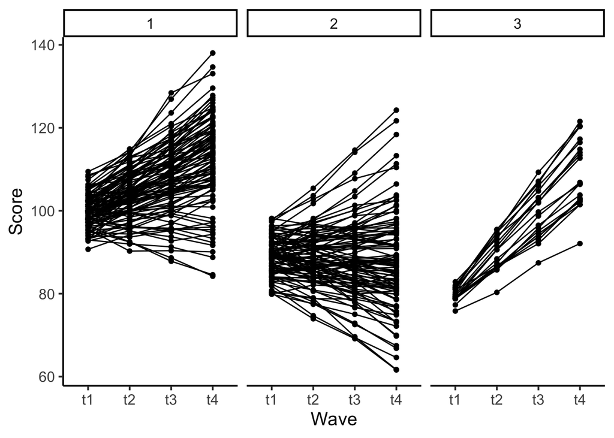

```r
#Plotting. Now you can start tweaking parameters to see what the data looks like
sim_sim_lgm_4waves_MG$id<-as.factor(1:nrow(sim_sim_lgm_4waves_MG))
sim_sim_lgm_4waves_MG$group<-as.factor(sim_sim_lgm_4waves_MG$group)
theme_set(theme_grey(base_size = 18)) #increase text size
plotdat<-melt(sim_sim_lgm_4waves_MG,id=c("id","group"))

ggplot(plotdat, aes(variable,value,group=id)) +
  geom_point() +
  geom_line() +
  theme_classic(base_size = 15) + # adding a classic theme; https://ggplot2.tidyverse.org/reference/ggtheme.html
  theme(legend.position = "none") + # getting rid of legend
  labs(x = "Wave", y = "Score") +
  facet_wrap(~group)
```

Simulating data can also be used for power analysis to test what effect size would be detected with your sample size and your model.

**Assignment 32: Use the previous simulate data model to test the effect size of a predictor on the slope.**

```r
#General specifications
nsims<-100                               #Define the number of iterations
samplesize<- 400                         #Define the sample size
modelcomp<-data.frame(matrix(NA,nsims,7)) #create empty object to store logicals for whether the correct model is preferred
colnames(modelcomp)<-c('effect size','#LRT delta chi square','LRT delta df','LRT pv-value','delta AIC','AIC logical')


# Create a matrix for the effect size tested
effectsize <- c(0,0.05,0.1,0.15,0.2,0.25,0.3)

power_effectsize<-data.frame(matrix(NA,length(effectsize),4))
colnames(power_effectsize)<-c('effect_size','powerLRT','powerAIC','powerAICthres')

# Display the resulting data frame
print(effectsize)
```

```
## [1] 0.00 0.05 0.10 0.15 0.20 0.25 0.30
```

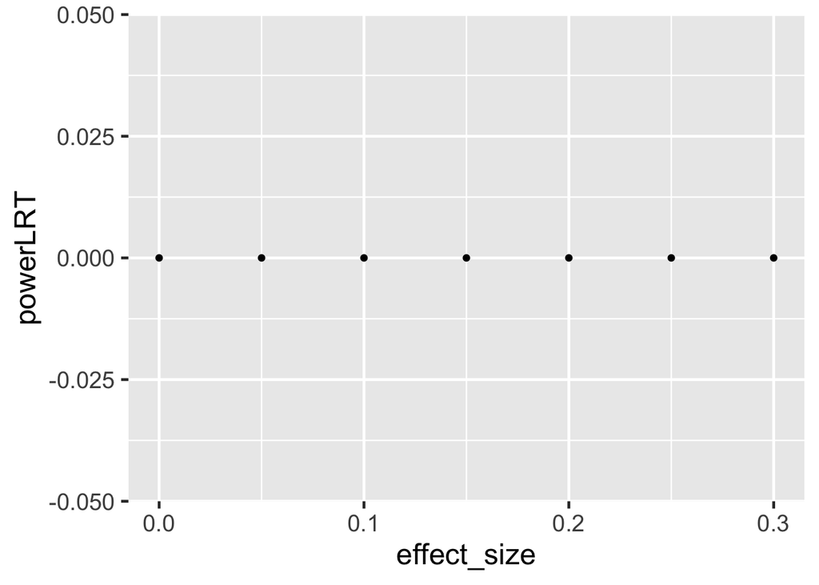

```r
a=0
for (j in 1:length(effectsize)) {
  effectsize[j]

for (i in 1:nsims) #initiate loop
{

  model_test<-NA   #change model output back to NA
  model_test_constraint<-NA   #change model output back to NA

  #Specify the true model
  #Simulate data for a bivariate Latent Change Score model
  model_sim_lgm_4waves<-
   paste('i =~ 1*t1 + 1*t2 + 1*t3 + 1*t4
          s =~ 0*t1 + 1*t2 + 2*t3 + 3*t4

          i~100*1         ##<## this specifies the intercept, or the mean at T1
          i~~15*i         ##<## this specifies the intercept variance at T1

          s~5*1           ##<## this specifies the slope, or change per wave
          s~~10*s         ##<## this specifies the slope variance

          i~~-3*s         ##<## this specifies the intercept/slope covariance

          pred~10*1         ##<## this specifies the pred, or the mean at T1
          pred~~5*pred         ##<## this specifies the pred variance at T1

          s~ ',effectsize[j],'*pred

         ')

#Simulate data
simdat_lgm_4waves<-simulateData(model_sim_lgm_4waves,sample.nobs = samplesize,meanstructure = T,empirical=TRUE)

#check if the parameters make sense with the number you provided
colMeans(simdat_lgm_4waves)

  model_test <- '
    i =~ 1*t1 + 1*t2 + 1*t3 + 1*t4
    s =~ 0*t1 + 1*t2 + 2*t3 + 3*t4
    i~~s
    s~ a*pred
'
  fit_model_test <- growth(model_test, data=simdat_lgm_4waves, estimator='mlr',missing='fiml')

  model_test_constraint <- '
    i =~ 1*t1 + 1*t2 + 1*t3 + 1*t4
    s =~ 0*t1 + 1*t2 + 2*t3 + 3*t4
    i~~s
    s~ 0*pred
'
  fit_model_test_constraint <- growth(model_test_constraint, data=simdat_lgm_4waves, estimator='mlr',missing='fiml')

  #Likelihood ratio test
  LRTcomp<-anova(fit_model_test,fit_model_test_constraint)
  modelaAIC<-AIC(fit_model_test) #grab AIC for the true model fit
  modelbAIC<-AIC(fit_model_test_constraint) #grab AIC for the competitor model fit

  modelcomp[i+a,1]<-effectsize[j]
  modelcomp[i+a,2]<-LRTcomp[2,5] #LRT chi square
  modelcomp[i+a,3]<-LRTcomp[2,6] #LRT delta df
  modelcomp[i+a,4]<-LRTcomp[2,7] #LRT p val
  modelcomp[i+a,5]<-modelbAIC-modelaAIC #delta AIC: positive means A preferred over B
  modelcomp[i+a,6]<-modelaAIC<modelbAIC #logical, does the alternative model have a
}
  power_effectsize[j,1]<- effectsize[j]
  powerLRT<-(sum(modelcomp[c((a+1):(a+100)),4]<0.05)/nsims)*100 #sum logical: divide by nsims to get percentage power
  power_effectsize[j,2]<- powerLRT
  powerAIC<-(sum(as.numeric(modelcomp[c((a+1):(a+100)),6]))/nsims)*100
  power_effectsize[j,3]<- powerAIC
  AICthres<-10
  powerAICthres<-sum(modelcomp[c((a+1):(a+100)),5]>10)/nsims*100
  power_effectsize[j,4]<- powerAICthres
  a=a+100
}

ggplot(power_effectsize,aes(effect_size,powerLRT))+
  geom_point()
```